# SVOG Awards

```python
!pip install numpy pandas matplotlib seaborn
```

```python
import pandas as pd
import numpy as np
import matplotlib.pyplot as plt
import seaborn as sns
```

```python
df = pd.read_csv('Hoja de cálculo sin título - Awards as of 7-5-22.csv')
```

```python
df.head()
```

|  | SVOG Total Awarded (Initial + Recon + Recon 2.0 + Supplemental) | SVOG Grantee | Address | City | State | Zip | Account Venue | Awarded Date* |
| --- | --- | --- | --- | --- | --- | --- | --- | --- |
| 0 | $ 543.571 | 'Murica LLC - SVOG | 1742 Greeley Mall | Greeley | CO | 80631 | Live venue operator or promoter | 9/9/2021 |
| 1 | $ 7.517.320 | "MELECO,LLC." - SVOG | P.O. Box 5864 | Incline Village | NV | 89450 | Live performing arts organization operator | 17/6/2021 |
| 2 | $ 434.788 | (The) Odeum Corporation - SVOG | 59 Main Street | East Greenwich | RI | 02818 | Live venue operator or promoter | 15/6/2021 |
| 3 | $ 730.591 | 1% Productions LLC - SVOG | 6212 Maple Street | Omaha | NE | 68104 | Live venue operator or promoter | 7/7/2021 |
| 4 | $ 75.461 | 10,000 Laughs LLC - SVOG | 2614 37th Ave. NE | St. Anthony | MN | 55421 | Live venue operator or promoter | 19/8/2021 |

# Shuttered Venue Operators Grant (SVOG)

The Shuttered Venue Operators Grant (SVOG) program was established by the Economic Aid to Hard-Hit Small Businesses, Nonprofits, and Venues Act, and amended by the American Rescue Plan Act. The program includes over $16 billion in grants to shuttered venues, to be administered by SBA’s Office of Disaster Assistance.

Eligible applicants may qualify for grants equivalent to 45% of their gross earned revenue, with the maximum amount available for a single grant award of $10 million. $2 billion is reserved for eligible applications with up to 50 full-time employees.

SVOG provides emergency assistance for eligible performing arts businesses affected by COVID-19.

The SVOG program’s mission is to support the ongoing operations of eligible live venues and operators, live venue promoters, theatrical producers, talent representatives, live performing arts organization operators, museums, and motion picture theaters during the uncertain economic conditions caused by the COVID-19 pandemic.

```python
print(df.columns)
```

```
Index([' SVOG Total Awarded (Initial + Recon + Recon 2.0 + Supplemental) ',
       'SVOG Grantee', 'Address', 'City', 'State', 'Zip', 'Account Venue',
       'Awarded Date*'],
      dtype='object')
```

```python
df.rename(columns={' SVOG Total Awarded (Initial + Recon + Recon 2.0 + Supplemental) ': 'Total_Awarded'}, inplace=True)
```

```python
df.head()
```

|  | Total_Awarded | SVOG Grantee | Address | City | State | Zip | Account Venue | Awarded Date* |
| --- | --- | --- | --- | --- | --- | --- | --- | --- |
| 0 | $ 543.571 | 'Murica LLC - SVOG | 1742 Greeley Mall | Greeley | CO | 80631 | Live venue operator or promoter | 9/9/2021 |
| 1 | $ 7.517.320 | "MELECO,LLC." - SVOG | P.O. Box 5864 | Incline Village | NV | 89450 | Live performing arts organization operator | 17/6/2021 |
| 2 | $ 434.788 | (The) Odeum Corporation - SVOG | 59 Main Street | East Greenwich | RI | 02818 | Live venue operator or promoter | 15/6/2021 |
| 3 | $ 730.591 | 1% Productions LLC - SVOG | 6212 Maple Street | Omaha | NE | 68104 | Live venue operator or promoter | 7/7/2021 |
| 4 | $ 75.461 | 10,000 Laughs LLC - SVOG | 2614 37th Ave. NE | St. Anthony | MN | 55421 | Live venue operator or promoter | 19/8/2021 |

```python
data_type = df['Total_Awarded'].dtype
print(data_type)
```

```
object
```

```python
df['Total_Awarded'] = df['Total_Awarded'].str.strip()
df['Total_Awarded'] = df['Total_Awarded'].str.replace('.', '', regex=False)
df['Total_Awarded'] = df['Total_Awarded'].str.replace('[$,]', '', regex=True).str.replace('.', '', regex=False)
```

```python
df.head()
```

|  | Total_Awarded | SVOG Grantee | Address | City | State | Zip | Account Venue | Awarded Date* |
| --- | --- | --- | --- | --- | --- | --- | --- | --- |
| 0 | 543571 | 'Murica LLC - SVOG | 1742 Greeley Mall | Greeley | CO | 80631 | Live venue operator or promoter | 9/9/2021 |
| 1 | 7517320 | "MELECO,LLC." - SVOG | P.O. Box 5864 | Incline Village | NV | 89450 | Live performing arts organization operator | 17/6/2021 |
| 2 | 434788 | (The) Odeum Corporation - SVOG | 59 Main Street | East Greenwich | RI | 02818 | Live venue operator or promoter | 15/6/2021 |
| 3 | 730591 | 1% Productions LLC - SVOG | 6212 Maple Street | Omaha | NE | 68104 | Live venue operator or promoter | 7/7/2021 |
| 4 | 75461 | 10,000 Laughs LLC - SVOG | 2614 37th Ave. NE | St. Anthony | MN | 55421 | Live venue operator or promoter | 19/8/2021 |

```python
descriptive_stats = df['Total_Awarded'].describe()
pd.set_option('display.float_format', '{:.4f}'.format)

print(descriptive_stats)
```

```
count         13011
unique        12576
top        10000000
freq            281
Name: Total_Awarded, dtype: object
```

```python
pd.set_option('display.float_format', '{:.3f}'.format)
df['Total_Awarded'] = df['Total_Awarded'].round(3)
df['Total_Awarded'] = pd.to_numeric(df['Total_Awarded'], errors='coerce')

descriptive_stats_all = df['Total_Awarded'].describe(percentiles=[.25, .5, .75, .90, .95, .99])
print(descriptive_stats_all)
```

```
count      13009.000
mean     1120322.343
std      2090492.874
min            3.000
25%       100370.000
50%       302648.000
75%       988279.000
90%      3084149.400
95%      6235091.000
99%     10000000.000
max     10000000.000
Name: Total_Awarded, dtype: float64
```

```python
distribution = df['Total_Awarded'].value_counts()
print(distribution)
```

```
Total_Awarded
10000000.000    281
8000000.000      39
80000.000         3
8100.000          3
68485.000         3
               ...
222298.000        1
2861415.000       1
51179.000         1
51523.000         1
203528.000        1
Name: count, Length: 12575, dtype: int64
```

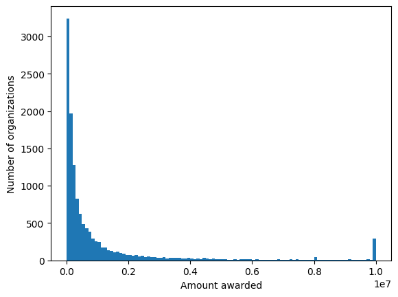

```python
plt.hist(df['Total_Awarded'], bins=100, range=(0, 10000000))
plt.xlabel('Amount awarded')
plt.ylabel('Number of organizations')
plt.show()
```

The number of businesses that received SVOG is 13.011. However, data on the amount given to them is available only for 13009 organizations, the other two have no record of that. On average, each business received $1.120.322$, with the minimun being $3$ and the maximum $10.000.000$. The median aid received was $302.648$, and the 75% percetile got $988.279$, below the mean.

```python
df['State'] = df['State'].str.upper()

businesses_per_state = df['State'].value_counts()
print(businesses_per_state)
```

```
State
CA    1981
NY    1475
TX     758
FL     747
IL     501
PA     438
OH     388
WA     335
MA     331
NC     330
GA     323
TN     313
MI     291
CO     280
NJ     261
OR     259
MN     252
WI     238
MO     228
VA     226
NV     225
AZ     203
LA     174
IN     171
MD     170
CT     155
IA     136
SC     121
KY     116
KS     115
UT     114
OK     105
AL     103
ME      93
NM      90
NE      87
HI      78
DC      78
AR      74
PR      69
VT      65
NH      60
MT      60
ID      58
RI      51
MS      47
AK      42
WV      41
SD      38
DE      36
ND      34
WY      33
GU      12
VI       2
Name: count, dtype: int64
```

```python
descriptive_stats_state = df['State'].describe()
print(descriptive_stats_state)
```

```
count     13011
unique       54
top          CA
freq       1981
Name: State, dtype: object
```

```python
category_counts = df['Account Venue'].value_counts()
print(category_counts)
```

```
Account Venue
Live venue operator or promoter               4824
Live performing arts organization operator    3396
Motion picture theater operator               1621
Talent representative                         1404
Theatrical producer                            951
Museum Operator                                815
Name: count, dtype: int64
```

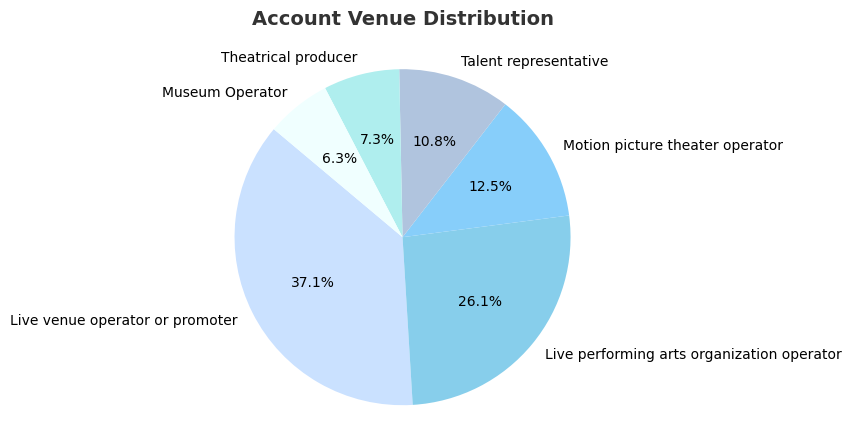

```python
category_counts = df['Account Venue'].value_counts()
category_percentages = category_counts / category_counts.sum() * 100

plt.pie(category_counts, labels=category_counts.index, autopct='%1.1f%%', startangle=140, colors=['#CAE1FF', '#87CEEB', '#87CEFA', '#B0C4DE', '#AFEEEE', '#F0FFFF'])
plt.axis('equal')
plt.title('Account Venue Distribution', pad=20, fontsize=14, fontweight='bold', color='#333333')
plt.show()
```

```python
state_category_counts = df.groupby('State')['Account Venue'].value_counts()
print(state_category_counts)
```

```
State  Account Venue
AK     Live performing arts organization operator    14
       Live venue operator or promoter               13
       Motion picture theater operator                6
       Museum Operator                                5
       Theatrical producer                            3
                                                     ..
WY     Live venue operator or promoter                7
       Live performing arts organization operator     4
       Theatrical producer                            3
       Museum Operator                                2
       Talent representative                          1
Name: count, Length: 309, dtype: int64
```

[figure not shown]

```python
state_category_counts.plot(kind='barh', stacked=False, figsize=(12, 50))
plt.title('Account Venue Counts by State')
plt.xlabel('State')
plt.ylabel('Number of businesses')
plt.show()
```

```python
df['Awarded Date*'] = pd.to_datetime(df['Awarded Date*'], format='%d/%m/%Y')
df['Month'] = df['Awarded Date*'].dt.month
grants_by_month = df['Month'].value_counts()
most_grants_month = grants_by_month.idxmax()

print("The month with the most grants awarded is:", most_grants_month)
```

```
The month with the most grants awarded is: 7
```

```python
df['Awarded Date*'] = pd.to_datetime(df['Awarded Date*'], format='%d/%m/%Y')
df['Month'] = df['Awarded Date*'].dt.month
grants_by_month = df['Month'].value_counts()
most_grants_month = grants_by_month.idxmin()

print("The month with the least grants awarded is:", most_grants_month)
```

```
The month with the least grants awarded is: 1
```

```python
!pip install squarify
```

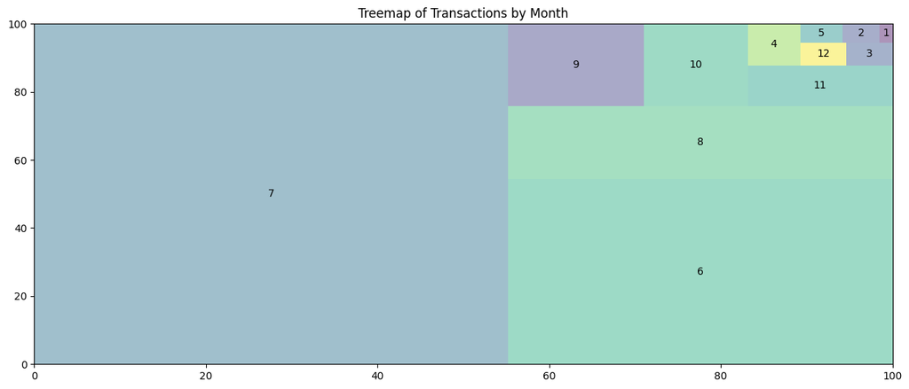

```python
import squarify

df['Awarded Date*'] = pd.to_datetime(df['Awarded Date*'], format='%d/%m/%Y')

df['Month'] = df['Awarded Date*'].dt.month
transactions_by_month = df['Month'].value_counts()

colors = ["#395a7f", "#6e9fc1", "#a3cae9", "#e9ecee", "#acacac", "#001840", "#102a71", "#f5c400", "#ffdc5f", "#fffdf0", "#009dd1", "#97e7f5"]

plt.figure(figsize=(15, 6))
squarify.plot(sizes=transactions_by_month, label=transactions_by_month.index, alpha=0.45)
plt.axis('on')
plt.title('Treemap of Transactions by Month')
plt.show()
```

[figure not shown]

```python
df['Awarded Date*'] = pd.to_datetime(df['Awarded Date*'], format='%d/%m/%Y')
df['Month'] = df['Awarded Date*'].dt.month
transactions_by_month = df['Month'].value_counts()
total_awarded_by_month = df.groupby('Month')['Total_Awarded'].sum().sort_index()

transactions_by_month.plot(kind='bar', stacked=False, figsize=(12, 6))
total_awarded_by_month.plot(kind='bar', color='skyblue')
plt.title('Account Venue Counts by Month')
plt.xlabel('Month')
plt.ylabel('Number of businesses')
plt.show()
```

Live venue operators or promoters and lLive performing arts organization operatos were the businesses that benefited the most from the assistance program. Months with the most amount of aids granted were June, July and August, with July leading the them

```python
ca_df = df[df['State'] == 'CA']
ca_df.head()
```

[output not shown]

```python
city_classifications = ca_df.groupby('City')
city_organization_count = ca_df['City'].value_counts().reset_index()
city_organization_count.columns = ['City', 'Organization Count']
print(city_organization_count)
```

```
               City  Organization Count
0       Los Angeles                 285
1     San Francisco                 136
2         San Diego                  94
3            Encino                  62
4            ENCINO                  51
..              ...                 ...
481          Linden                   1
482  VALLEY VILLAGE                   1
483   Half Moon Bay                   1
484      NORTHRIDGE                   1
485        Brisbane                   1

[486 rows x 2 columns]
```

```python
city_organization_count.head(10)
```

|  | City | Organization Count |
| --- | --- | --- |
| 0 | Los Angeles | 285 |
| 1 | San Francisco | 136 |
| 2 | San Diego | 94 |
| 3 | Encino | 62 |
| 4 | ENCINO | 51 |
| 5 | Beverly Hills | 38 |
| 6 | Oakland | 32 |
| 7 | Berkeley | 28 |
| 8 | San Jose | 27 |
| 9 | Sacramento | 27 |

```python
relative_frequency = ca_df['City'].value_counts(normalize=True) * 100
print(relative_frequency)
```

```
City
Los Angeles      14.387
San Francisco     6.865
San Diego         4.745
Encino            3.130
ENCINO            2.574
                  ...
Linden            0.050
VALLEY VILLAGE    0.050
Half Moon Bay     0.050
NORTHRIDGE        0.050
Brisbane          0.050
Name: proportion, Length: 486, dtype: float64
```

Given that California is the state in which the most amount of grants were given, I decided to zoom in. More than 30% of businesses were located in Los Angeles, San Francisco, Encino and San Diego, with half of that coming from organizations based in LA.

```python
ny_df = df[df['State'] == 'NY']
ny_df.head()
```

[output not shown]

```python
city_classifications_ny = ny_df.groupby('City')
city_organization_count_ny = ny_df['City'].value_counts().reset_index()
city_organization_count_ny.columns = ['City', 'Organization Count']
print(city_organization_count_ny)
```

```
              City  Organization Count
0         New York                 571
1         Brooklyn                 167
2         NEW YORK                  62
3          Buffalo                  32
4        Rochester                  25
..             ...                 ...
325  Bovina Center                   1
326       Blasdell                   1
327   Orchard Park                   1
328      Northport                   1
329         Oswego                   1

[330 rows x 2 columns]
```

```python
relative_frequency_ny = ny_df['City'].value_counts(normalize=True) * 100
print(relative_frequency_ny)
```

```
City
New York        38.712
Brooklyn        11.322
NEW YORK         4.203
Buffalo          2.169
Rochester        1.695
                 ...
Bovina Center    0.068
Blasdell         0.068
Orchard Park     0.068
Northport        0.068
Oswego           0.068
Name: proportion, Length: 330, dtype: float64
```

New York came number 2 as the state with the most amount of beneficiaries. More than 55% of the businesses were located in New York City, Brooklyn, Buffalo and Rochester, with NYC leading the way with 42.9% of the total.

```python
most_prevalent_venue = ca_df['Account Venue'].value_counts().idxmax()
print("The most prevalent Account Venue in the state is:", most_prevalent_venue)
```

```
The most prevalent Account Venue in the state is: Live venue operator or promoter
```

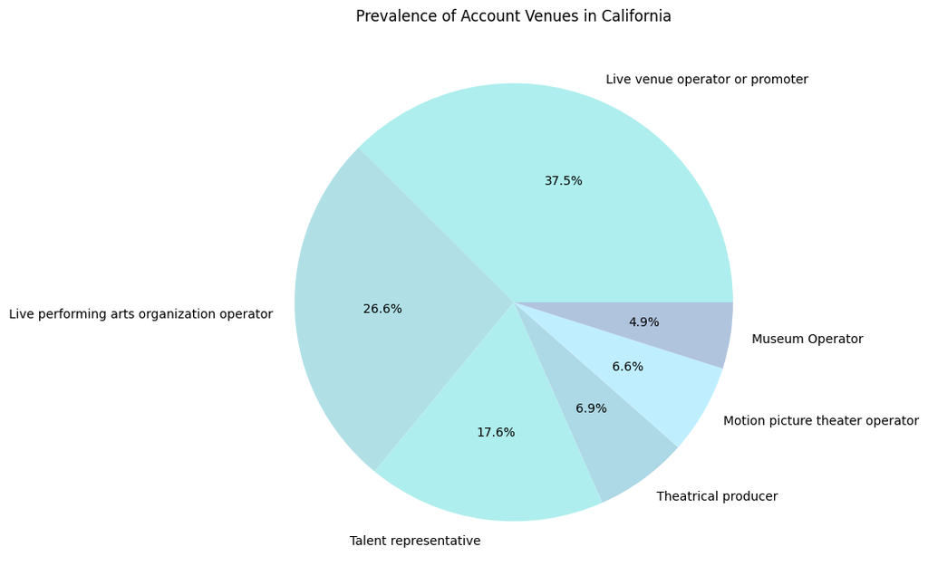

```python
colors = ['#AEEEEE', '#B0E0E6', '#AFEEEE', '#ADD8E6', '#BFEFFF', '#B0C4DE']

venue_counts = ca_df['Account Venue'].value_counts()
plt.figure(figsize=(8, 8))
plt.pie(venue_counts, labels=venue_counts.index, colors=colors, autopct='%1.1f%%')
plt.title('Prevalence of Account Venues in California')
plt.show()
```

```python
most_prevalent_venue_ny = ny_df['Account Venue'].value_counts().idxmax()
print("The most prevalent Account Venue in the state is:", most_prevalent_venue)
```

```
The most prevalent Account Venue in the state is: Live venue operator or promoter
```

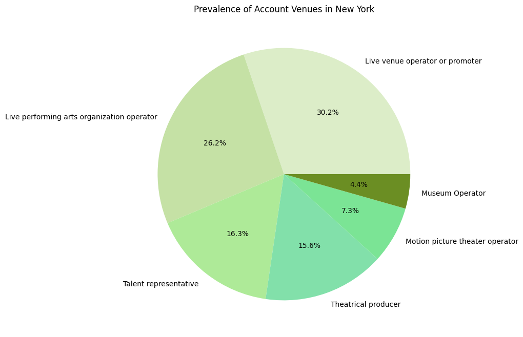

```python
colors = ['#DCEDC8', '#C5E1A5', '#AEEA98', '#82E0AA', '#7BE495', '#6B8E23']

venue_counts_ny = ny_df['Account Venue'].value_counts()
plt.figure(figsize=(8, 8))
plt.pie(venue_counts_ny, labels=venue_counts.index, colors=colors, autopct='%1.1f%%')
plt.title('Prevalence of Account Venues in New York')
plt.show()
```